# Introduction to Object-Oriented Programming

`super(), __init__?`

Specialist Analytics Team (SAT)

## Learning Objectives

- Understand core concepts of object-oriented programming
- Understand the benefits of object-oriented programming
- Learn how to create your own object classes (see the accompanying notebook)

## Object-Oriented Programming? What is this tech-geekery and why should I care?

- Python is an object-oriented language. Every entity is treated as an object; even single integers are objects of the “int” class.
- An understanding of object-oriented programming will help give you a better understanding of how the packages you use function.
- You can use this understanding to create your own programs that harness the strengths of objected-oriented programming:
  - Convenience
  - Flexibility
  - Extensibility
  - Simpler interfacing

## History

- In the early days of programming, variables could only be the “primitive” data types containing a single value
  - Integer, Float, Boolean, Char
- Later came Structures (“Structs”), which can contain multiple values of different types.
- Structs were the precursor to objects, but they couldn’t yet contain associated functions within them.
- Objects first appear in the Simula programming language in the 1960s for modelling physical phenomena.
- Those objects influenced Alan Kay, who coined the term “object-oriented programming” to describe architecture where objects pass information to one another.

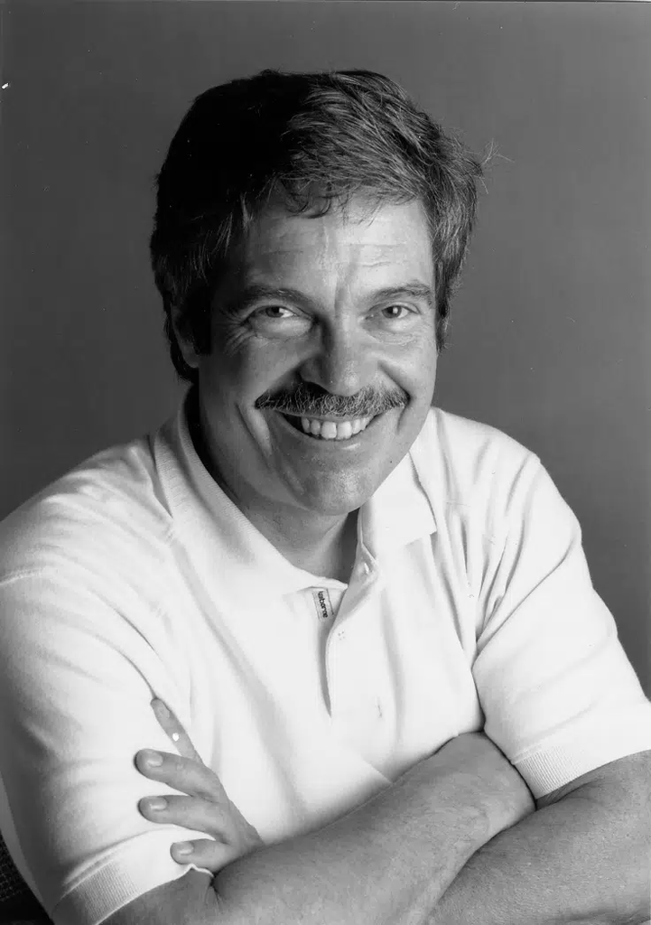

My. Kay looking very pleased with his coinage.

## Classes and Objects

- Classes act as **templates** for objects
- Objects are referred to as “instances” of classes
  - We talk of objects being “instantiated” from a class
  - Think of each object as being a copy created using the class template
- Objects represent entities with their own data (attributes) and behaviours (methods)
- We can create lots of instances of an object with their own attribute values and call methods on them separately yet *consistently*
- Objects are self-contained units that can interact with objects both of the same and of other classes

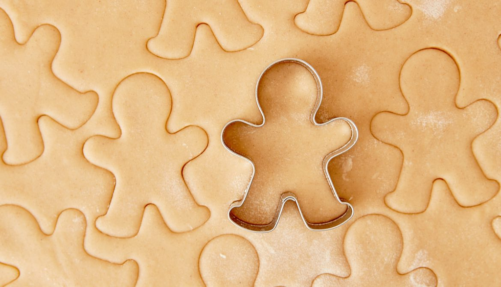

Consistency is the key.

# The Anatomy of a Class

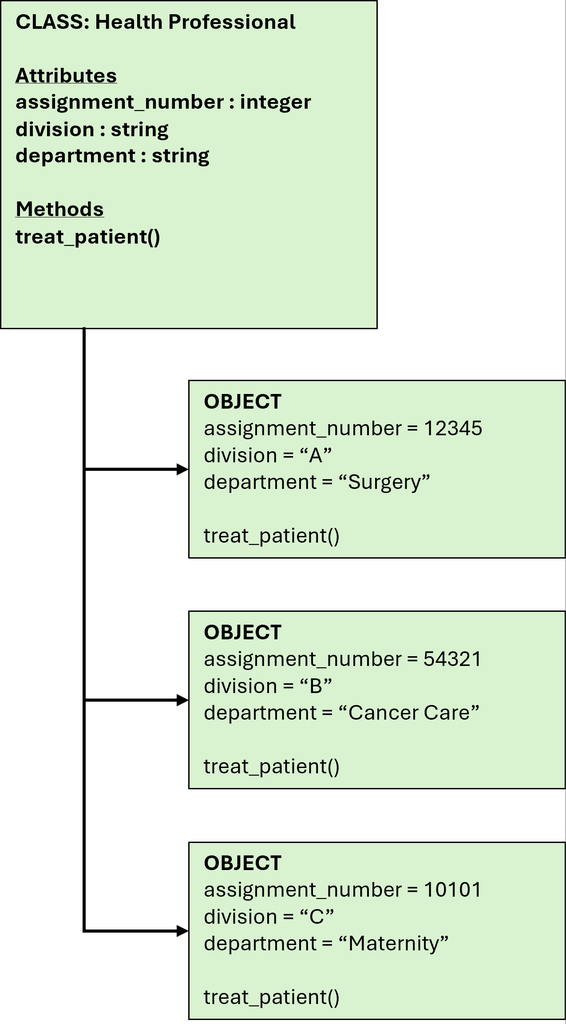

A diagram representing a class at the top and object instances created from the class

## Inheritance

- **Child classes inherit attributes and methods from parent classes**
- Child classes can modify / override and add to what they have inherited
- Reduces code duplication; increases re-usability
- Improves extensibility: i.e. new classes with the same core behaviours, but new features, can be based on existing classes

[figure not shown]

Inheritance is a much less contentious issue in Python.

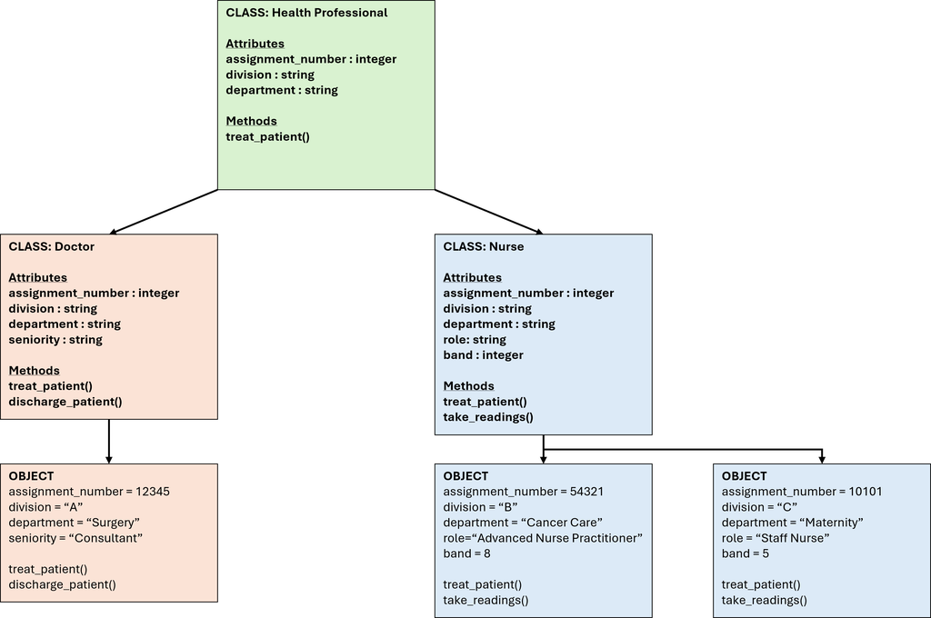

A parent class (green) and two different child classes (blue and orange), each with objects created from them

# More Object-Oriented Programming Concepts

## Encapsulation *for convenience*

- **Bundling data (attributes) with functions (methods)**
- Methods are tailor-made to work with the data contained in the object
- Saves on having to pass data between multiple functions, which is particularly useful in machine learning models
- Pandas DataFrames demonstrate encapsulation. They contain data, but also have methods associated with them
  - `df = pd.DataFrame(data)` <– Instantiating a dataframe object
  - `df.head()`, `df.describe()`, `df.drop()` <– calling methods

## Polymorphism *for flexibility*

- **Objects of different types can be treated in the same way, even if the behaviour differs**
  - With Pandas DataFrames, .head() will work on both a DataFrame and a Series<sup>1</sup>
- “Duck typing”: If the behaviour of a thing matches that of another thing, they are considered the same. In OOP terms, the presence of certain methods is more important than which class an object comes from<sup>2</sup>
  - The scikit-learn library’s allows the same code to work for different models
[^1]: Series.head() with return the first few values, while DataFrame.head() returns the first few rows of all columns
[^2]: The concept of “duck typing”, found in Python and other languages, comes from the phrase “if it walks like a duck, quacks like a duck and swims like a duck, then it’s a duck.”

## Abstraction *for simpler interfacing*

- **Separating the implementation code from the functionality that users (i.e. other programmers) interact with**
- Creates a simple interface for parts of a program pass information between each other
- Examples:
  - When working with machine learning models, users only need to apply simple methods to train the model and make a prediction.
  - Entities interacting with each other within a simulation model.

## Resources

[RealPython: Object-Oriented Programming (OOP) in Python](https://realpython.com/python3-object-oriented-programming/)  
[OOP produces code that is easy to read, extend and maintain](https://medium.com/@lawjimmy123/how-data-scientists-can-leverage-object-oriented-programming-oop-design-pattern-to-write-better-699166910882)  
[HSMA’s Guide to Object-Oriented Programming](https://docs.google.com/presentation/d/1e7ObbZmRNcm_lqxR_tFvwV78YV2SzBGSwWRweGiezYg/edit?slide=id.p1#slide=id.p1)  
[HSMA’s Discrete Event Simulation Module](https://hsma.co.uk/hsma_content/modules/current_module_details/2_des.html)

# Thank You!

Notebook & Slides:

[/NHS-South-Central-and-West/code-club](https://nhs-south-central-and-west.github.io/code-club/sessions/essential-skills/09-object-oriented-programming/)

… And don’t forget to give us your [feedback](https://forms.office.com/e/g9fnSVPRwE).